# **NOTE:** Use File > Save a copy in Drive to make a copy before doing anything else

# Project 7: Data Exploration and Visualization

### Overview

In this project, you will apply data exploration and visualization techniques to a real-world dataset of your choice. You'll practice using pandas for data analysis and create meaningful visualizations to gain insights from your data. This project builds on your Python programming skills while introducing you to the exciting world of data science.

In [Lab7](https://colab.research.google.com/drive/15QvSh0csZaCU-OuuPIfpWx5wLDDjmqK4?usp=sharing), you explore the titanic dataset and you should use it as a sample and pick a dataset of your interest to do a similar data exploration and visualization.

### Project Objectives

- Find and select a dataset from a real-world data source
- Formulate a clear inquiry question based on your chosen dataset
- Perform exploratory data analysis using pandas functions
- Create at least two meaningful data visualizations
- Analyze your findings and answer your inquiry question
- Reflect on the insights gained through data exploration

### Data Sources

You can choose from various online data sources such as:

- [Kaggle](https://www.kaggle.com/datasets) - Wide variety of datasets
- [data.gov](https://www.data.gov/) - U.S. government data
- [Our World in Data](https://ourworldindata.org/) - Global development data
- [GitHub](https://github.com/datasets) - Curated datasets
- [Google Dataset Search](https://datasetsearch.research.google.com/) - Search for datasets
- Or any other reliable data source you find interesting

## Part 1: Dataset Selection and Initial Exploration

#### TODO Tasks:

1. Select Your Dataset: Choose a dataset that interests you. Make sure it has at least 100 rows and multiple columns with different data types (e.g., numerical, categorical, dates).

Please create either text or code cells in between the TODO tasks to do the work.

2. Import Libraries: Import the necessary libraries (pandas, matplotlib, seaborn) at the beginning of your notebook by creating code cells below this text cell.

```python
!pip install pandas==2.2.2
!pip install seaborn==0.13.2
!pip install matplotlib==3.8.0
```

3. Load Your Data: Load your chosen dataset using pandas and save it to a pandas dataframe. Please create a code cell below this text cell to do it.

```python
# @title Load the data
import pandas as pd

URL = "https://raw.githubusercontent.com/elizahardy/elizahardy.github.io/refs/heads/main/International_Education_Costs.csv"
df = pd.read_csv(URL)
```

4. Data Summary: Use the following functions to do inital exploration your dataset:
- info() - Display information about the dataset structure
- describe() - Show statistical summary of numerical columns
- head() - Display the first 5 rows (df.head())
- shape - Show the dimensions of the dataset (e.g. df.shape)
- columns - Get the column names (e.g. df.columns)

You may use 5 code cells below this text cell to accomplish it.

```python
# Info

df.info()
```

```
<class 'pandas.core.frame.DataFrame'>
RangeIndex: 907 entries, 0 to 906
Data columns (total 12 columns):
 #   Column             Non-Null Count  Dtype
---  ------             --------------  -----
 0   Country            907 non-null    object
 1   City               907 non-null    object
 2   University         907 non-null    object
 3   Program            907 non-null    object
 4   Level              907 non-null    object
 5   Duration_Years     907 non-null    float64
 6   Tuition_USD        907 non-null    int64
 7   Living_Cost_Index  907 non-null    float64
 8   Rent_USD           907 non-null    int64
 9   Visa_Fee_USD       907 non-null    int64
 10  Insurance_USD      907 non-null    int64
 11  Exchange_Rate      907 non-null    float64
dtypes: float64(3), int64(4), object(5)
memory usage: 85.2+ KB
```

```python
# Describe

df.describe(include='all')
```

|  | Country | City | University | Program | Level | Duration_Years | Tuition_USD | Living_Cost_Index | Rent_USD | Visa_Fee_USD | Insurance_USD | Exchange_Rate |
| --- | --- | --- | --- | --- | --- | --- | --- | --- | --- | --- | --- | --- |
| count | 907 | 907 | 907 | 907 | 907 | 907.000000 | 907.000000 | 907.000000 | 907.000000 | 907.000000 | 907.000000 | 907.000000 |
| unique | 71 | 556 | 622 | 92 | 3 | NaN | NaN | NaN | NaN | NaN | NaN | NaN |
| top | UK | Singapore | University of Washington | Computer Science | Master | NaN | NaN | NaN | NaN | NaN | NaN | NaN |
| freq | 93 | 18 | 6 | 312 | 451 | NaN | NaN | NaN | NaN | NaN | NaN | NaN |
| mean | NaN | NaN | NaN | NaN | NaN | 2.836825 | 16705.016538 | 64.437486 | 969.206174 | 211.396913 | 700.077178 | 623.000695 |
| std | NaN | NaN | NaN | NaN | NaN | 0.945449 | 16582.385275 | 14.056333 | 517.154752 | 143.435740 | 320.374875 | 3801.746134 |
| min | NaN | NaN | NaN | NaN | NaN | 1.000000 | 0.000000 | 27.800000 | 150.000000 | 40.000000 | 200.000000 | 0.150000 |
| 25% | NaN | NaN | NaN | NaN | NaN | 2.000000 | 2850.000000 | 56.300000 | 545.000000 | 100.000000 | 450.000000 | 0.920000 |
| 50% | NaN | NaN | NaN | NaN | NaN | 3.000000 | 7500.000000 | 67.500000 | 900.000000 | 160.000000 | 650.000000 | 1.350000 |
| 75% | NaN | NaN | NaN | NaN | NaN | 4.000000 | 31100.000000 | 72.200000 | 1300.000000 | 240.000000 | 800.000000 | 7.150000 |
| max | NaN | NaN | NaN | NaN | NaN | 5.000000 | 62000.000000 | 122.400000 | 2500.000000 | 490.000000 | 1500.000000 | 42150.000000 |

```python
# Head

df.head()
```

|  | Country | City | University | Program | Level | Duration_Years | Tuition_USD | Living_Cost_Index | Rent_USD | Visa_Fee_USD | Insurance_USD | Exchange_Rate |
| --- | --- | --- | --- | --- | --- | --- | --- | --- | --- | --- | --- | --- |
| 0 | USA | Cambridge | Harvard University | Computer Science | Master | 2.0 | 55400 | 83.5 | 2200 | 160 | 1500 | 1.00 |
| 1 | UK | London | Imperial College London | Data Science | Master | 1.0 | 41200 | 75.8 | 1800 | 485 | 800 | 0.79 |
| 2 | Canada | Toronto | University of Toronto | Business Analytics | Master | 2.0 | 38500 | 72.5 | 1600 | 235 | 900 | 1.35 |
| 3 | Australia | Melbourne | University of Melbourne | Engineering | Master | 2.0 | 42000 | 71.2 | 1400 | 450 | 650 | 1.52 |
| 4 | Germany | Munich | Technical University of Munich | Mechanical Engineering | Master | 2.0 | 500 | 70.5 | 1100 | 75 | 550 | 0.92 |

```python
# Shape

print(f"{df.shape}: Number of rows: {df.shape[0]}, number of columns: {df.shape[1]}")
print('\n')
```

```
(907, 12): Number of rows: 907, number of columns: 12
```

```python
# Columns
columns = df.columns.tolist()
print(f"Column Names: ")
print('\n'.join(columns))
```

```
Column Names:
Country
City
University
Program
Level
Duration_Years
Tuition_USD
Living_Cost_Index
Rent_USD
Visa_Fee_USD
Insurance_USD
Exchange_Rate
```

5. Inquiry Question: Write a clear, specific question that you want to answer using your dataset by creating a text cell below and **write the question in bold please.**

For example:

- "How has the average temperature changed in major cities over the past decade?"
- "What factors are most strongly correlated with housing prices?"
- "Is there a relationship between education level and income?"

**How is tuition relevent to being an international student?**

## Part 2: Data Visualization and Analysis

#### TODO Tasks:

1. Data Cleaning (if necessary): Check for and handle any missing values, duplicates, or data quality issues.

**NOTE: This could be a daunting task even for seasoned data scientists. My suggestion is to use a dataset that is already clean if you can for the purpose of completing this assignment in a week.**

Examples:

- Checking for missing values: df.isnull().sum()
- Dropping rows with any missing values: df.dropna(inplace=True)
- Dropping columns with all missing values: df.dropna(axis=1, how='all', inplace=True)
- Removing duplicate row: df.drop_duplicates(inplace=True)
2. Create Visualizations: Create at least 2 different types of visualizations that help answer your research question. Choose from:
- Bar charts
- Line plots
- Scatter plots
- Histograms
- Box plots
- Heatmaps
- Any other appropriate visualization
3. Customize Your Plots: Make sure your visualizations are clear and informative by:
- Adding appropriate titles
- Labeling axes
- Using colors effectively
- Adding legends when necessary

Please create code cells below this to create your visualizations.

```python
# imports

from matplotlib import pyplot as plt
```

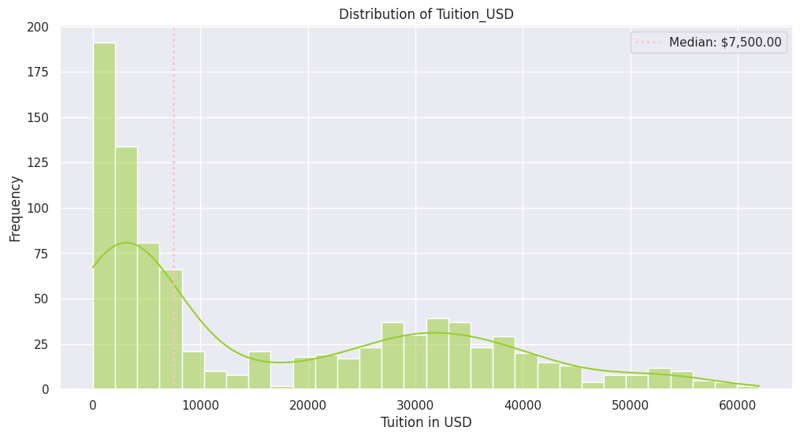

```python
# Tuition_USD

plt.figure(figsize=(12, 6))
sns.histplot(df['Tuition_USD'], kde=True, bins=30,color='yellowgreen')
median_tuition = df['Tuition_USD'].median()
plt.axvline(median_tuition, color='pink', linestyle='dotted', linewidth=2, label=f'Median: ${median_tuition:,.2f}')
plt.title('Distribution of Tuition_USD')
plt.xlabel('Tuition in USD')
plt.ylabel('Frequency')
plt.legend()
plt.show()
```

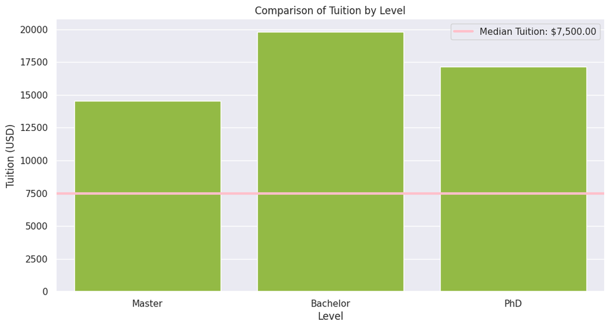

```python
# Tuition_USD vs Level
plt.figure(figsize=(12, 6))
sns.barplot(x='Level', y='Tuition_USD', data=df, errorbar=None, color='yellowgreen',)
overall_median_tuition = df['Tuition_USD'].median()
plt.axhline(overall_median_tuition, color='pink', linestyle='solid', linewidth=3, label=f'Median Tuition: ${overall_median_tuition:,.2f}')
plt.title('Comparison of Tuition by Level')
plt.xlabel('Level')
plt.ylabel('Tuition (USD)')
plt.legend()
plt.show()
```

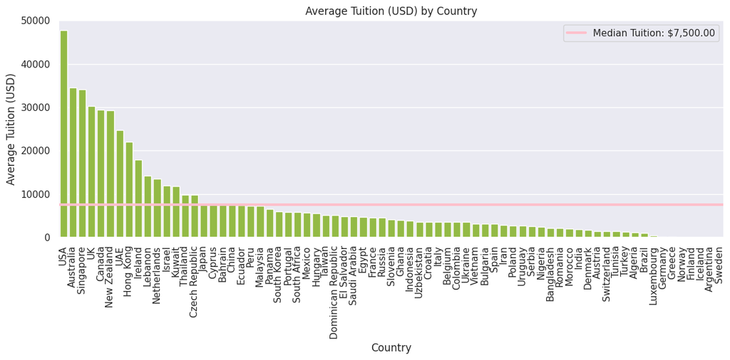

```python
# Tuition_USD vs Country

def plot_avg_tuition_by_country(dataframe):
  avg_tuition_by_country = dataframe.groupby('Country')['Tuition_USD'].mean().sort_values(ascending=False)

  plt.figure(figsize=(12, 6))
  sns.barplot(x=avg_tuition_by_country.index, y=avg_tuition_by_country.values, color='yellowgreen')
  plt.axhline(overall_median_tuition, color='pink', linestyle='solid', linewidth=3, label=f'Median Tuition: ${overall_median_tuition:,.2f}',)
  plt.xticks(rotation=90)
  plt.title('Average Tuition (USD) by Country')
  plt.xlabel('Country')
  plt.ylabel('Average Tuition (USD)')
  plt.tight_layout()
  plt.legend()
  plt.show()

plot_avg_tuition_by_country(df)
```

4. Analysis: Write 1-2 paragraphs discussing:
- Whether your research question can be answered with the available data
- What insights you discovered through your visualizations
- Any unexpected or interesting findings
- Limitations of your analysis
- Suggestions for further investigation

Please create a text cell below this cell to write your analysis.

My question, how is tuition relevent to being an international student, was somewhat answered by the given data and the visualisations I made from it. With the visualizations I utilized, I found that the US was the most expensive place to study and a bachelors degree was highest costing level of education. This is not suprising as the US puts little money into subsidizing education outside of loans. In addition, getting a bachelors degree takes the most amount of time so it made sense that it was the most expensive level of education. I found it interesting that the median for tuition was below $10000 USD as that is very uncommon in the US without scholarships. While looking at the data, I noticed that most majors covered were related to STEM and Business which can have different pricepoints to other disciplines such as Art and Humanities that require a lot of supplies/readings. This could potentially impact where the median is placed. The median also could have been different than the true median because the universities selected where some of the top ranked which tend to be more expensive due to prestige. If feaseable I would recomend that the data should either stick to one major or have an average tuition cost for the institution. Another thing that could improve that data would be to get tuition costs from a wider range of universities so it is more representatve. I think it could be interesting to also look at if there are differences between the countries students are coming from and going to and looking at additional costs that could vary such as visas.

## NOTE: If you use a local dataset, you MUST submit the dataset along with your notebook to get credit.

- Download your notebook as CS110_Project7.ipynb
- Ensure all TODO tasks are completed
- Make sure your code runs without errors
- Include clear comments explaining your work
- Submit the notebook file

## Grading Criteria (4 points)

- Dataset Selection: Appropriate choice of dataset with sufficient complexity
- Inquiry Question: Clear, specific, and answerable with the chosen data
- Data Exploration: Proper use of pandas functions for initial analysis
- Visualizations: At least 2 clear, well-formatted, and relevant plots
- Analysis: Thoughtful interpretation of findings and answer to research question
- Code Quality: Clean, commented, and well-organized code

Remember: The goal is not just to create visualizations, but to use them to gain meaningful insights about your data. Think like a data scientist and let your curiosity guide your exploration!